# Program Summary - Program 1

### Program Summary - Program 1

### Execution Environment

| Author: | u59814750 |
| --- | --- |
| File: |  |
| SAS Platform: | Linux LIN X64 3.10.0-1062.9.1.el7.x86_64 |
| SAS Host: | ODAWS01-EUW1.ODA.SAS.COM |
| SAS Version: | 9.04.01M6P11072018 |
| SAS Locale: | tr_TR |
| Submission Time: | 30.01.2022 18:53:49 |
| Browser Host: | 178.233.117.30 |
| User Agent: | Mozilla/5.0 (Macintosh; Intel Mac OS X 10_15_7) AppleWebKit/537.36 (KHTML, like Gecko) Chrome/97.0.4692.99 Safari/537.36 |
| Application Server: | ODAMID00-EUW1.ODA.SAS.COM |

### Code: Program 1

/* Generated Code (IMPORT) */

/* Source File: breast_canser_data.csv */

/* Source Path: /home/u59814750/ecem_breast_canser_data */

/* Code generated on: 30.01.2022 18:50 */

%web_drop_table(WORK.IMPORT1);

FILENAME REFFILE '/home/u59814750/ecem_breast_canser_data/breast_canser_data.csv';

PROC IMPORT DATAFILE=REFFILE

DBMS=CSV

OUT=WORK.IMPORT1;

GETNAMES=YES;

RUN;

PROC CONTENTS DATA=WORK.IMPORT1; RUN;

%web_open_table(WORK.IMPORT1);

proc means data = IMPORT1;

var Protein2 Protein3 Protein4 ;

run;

proc freq data = IMPORT1;

table Surgery_type ;

run;

/*Tek yonlu manova*/

proc glm data = IMPORT1;

class Surgery_type ;

model Protein2 Protein3 Protein4 = Surgery_type / SS3;

manova h = Surgery_type;

run;

/*etkilesimli*/

proc glm data = IMPORT1;

class Surgery_type Tumour_stage ;

model Protein2 Protein3 Protein4 = Tumour_stage*Surgery_type / SS3;

manova h = Tumour_stage*Surgery_type ;

run;

### Log: Program 1

Notes (15)

[output not shown]

### Results: Program 1

The CONTENTS Procedure

| Data Set Name | WORK.IMPORT1 | Observations | 321 |
| --- | --- | --- | --- |
| Member Type | DATA | Variables | 13 |
| Engine | V9 | Indexes | 0 |
| Created | 30.01.2022 18:53:47 | Observation Length | 136 |
| Last Modified | 30.01.2022 18:53:47 | Deleted Observations | 0 |
| Protection |  | Compressed | NO |
| Data Set Type |  | Sorted | NO |
| Label |  |  |  |
| Data Representation | SOLARIS_X86_64, LINUX_X86_64, ALPHA_TRU64, LINUX_IA64 |  |  |
| Encoding | utf-8 Unicode (UTF-8) |  |  |

[output not shown]

| Alphabetic List of Variables and Attributes # | Alphabetic List of Variables and Attributes Variable | Alphabetic List of Variables and Attributes Type | Alphabetic List of Variables and Attributes Len | Alphabetic List of Variables and Attributes Format | Alphabetic List of Variables and Attributes Informat |
| --- | --- | --- | --- | --- | --- |
| 1 | Age | Num | 8 | BEST12. | BEST32. |
| 9 | ER_status | Char | 8 | $8. | $8. |
| 2 | Gender | Char | 6 | $6. | $6. |
| 11 | HER1_status | Num | 8 | BEST12. | BEST32. |
| 8 | Histology | Char | 30 | $30. | $30. |
| 10 | PR_status | Char | 8 | $8. | $8. |
| 13 | Patient_Status | Char | 5 | $5. | $5. |
| 3 | Protein1 | Num | 8 | BEST12. | BEST32. |
| 4 | Protein2 | Num | 8 | BEST12. | BEST32. |
| 5 | Protein3 | Num | 8 | BEST12. | BEST32. |
| 6 | Protein4 | Num | 8 | BEST12. | BEST32. |
| 12 | Surgery_type | Char | 27 | $27. | $27. |
| 7 | Tumour_Stage | Char | 3 | $3. | $3. |

The MEANS Procedure

| Variable | N | Mean | Std Dev | Minimum | Maximum |
| --- | --- | --- | --- | --- | --- |
| Protein2 Protein3 Protein4 | 321 321 321 | 0.9545634 -0.0932785 0.0088128 | 0.9096351 0.5879807 0.6224914 | -0.9787300 -1.6274000 -2.0255000 | 3.4022000 2.1934000 1.6299000 |

The FREQ Procedure

| Surgery_type | Frequency | Percent | Cumulative Frequency | Cumulative Percent |
| --- | --- | --- | --- | --- |
| Lumpectomy | 66 | 20.56 | 66 | 20.56 |
| Modified_Radical_Mastectomy | 92 | 28.66 | 158 | 49.22 |
| Other | 98 | 30.53 | 256 | 79.75 |
| Simple_Mastectomy | 65 | 20.25 | 321 | 100.00 |

The GLM Procedure

| Class Level Information Class | Class Level Information Levels | Class Level Information Values |
| --- | --- | --- |
| Surgery_type | 4 | Lumpectomy Modified_Radical_Mastectomy Other Simple_Mastectomy |

| Number of Observations Read | 321 |
| --- | --- |
| Number of Observations Used | 321 |

The GLM Procedure

Dependent Variable: Protein2

| Source | DF | Sum of Squares | Mean Square | F Value | Pr > F |
| --- | --- | --- | --- | --- | --- |
| Model | 3 | 5.0670478 | 1.6890159 | 2.06 | 0.1052 |
| Error | 317 | 259.7124756 | 0.8192823 |  |  |
| Corrected Total | 320 | 264.7795234 |  |  |  |

| R-Square | Coeff Var | Root MSE | Protein2 Mean |
| --- | --- | --- | --- |
| 0.019137 | 94.82263 | 0.905142 | 0.954563 |

| Source | DF | Type III SS | Mean Square | F Value | Pr > F |
| --- | --- | --- | --- | --- | --- |
| Surgery_type | 3 | 5.06704782 | 1.68901594 | 2.06 | 0.1052 |

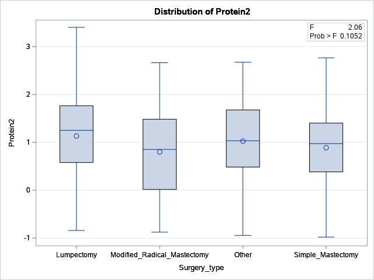

The GLM Procedure

Dependent Variable: Protein3

| Source | DF | Sum of Squares | Mean Square | F Value | Pr > F |
| --- | --- | --- | --- | --- | --- |
| Model | 3 | 1.7411422 | 0.5803807 | 1.69 | 0.1691 |
| Error | 317 | 108.8896910 | 0.3435006 |  |  |
| Corrected Total | 320 | 110.6308333 |  |  |  |

| R-Square | Coeff Var | Root MSE | Protein3 Mean |
| --- | --- | --- | --- |
| 0.015738 | -628.3217 | 0.586089 | -0.093279 |

| Source | DF | Type III SS | Mean Square | F Value | Pr > F |
| --- | --- | --- | --- | --- | --- |
| Surgery_type | 3 | 1.74114224 | 0.58038075 | 1.69 | 0.1691 |

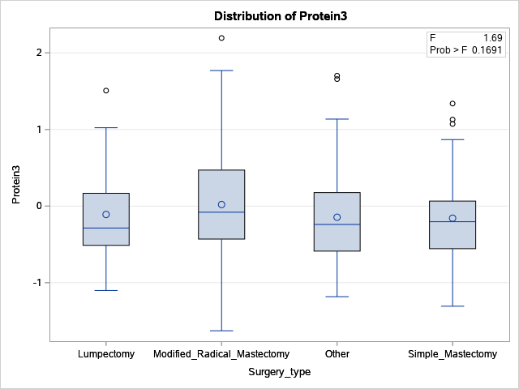

The GLM Procedure

Dependent Variable: Protein4

| Source | DF | Sum of Squares | Mean Square | F Value | Pr > F |
| --- | --- | --- | --- | --- | --- |
| Model | 3 | 1.7019943 | 0.5673314 | 1.47 | 0.2225 |
| Error | 317 | 122.2965932 | 0.3857937 |  |  |
| Corrected Total | 320 | 123.9985875 |  |  |  |

| R-Square | Coeff Var | Root MSE | Protein4 Mean |
| --- | --- | --- | --- |
| 0.013726 | 7047.965 | 0.621123 | 0.008813 |

| Source | DF | Type III SS | Mean Square | F Value | Pr > F |
| --- | --- | --- | --- | --- | --- |
| Surgery_type | 3 | 1.70199430 | 0.56733143 | 1.47 | 0.2225 |

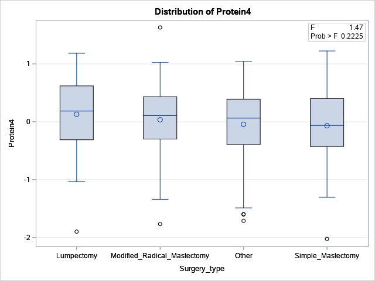

The GLM Procedure

Multivariate Analysis of Variance

| Characteristic Roots and Vectors of: E Inverse * H, where H = Type III SSCP Matrix for Surgery_type E = Error SSCP Matrix Characteristic Root | Characteristic Roots and Vectors of: E Inverse * H, where H = Type III SSCP Matrix for Surgery_type E = Error SSCP Matrix Percent | Characteristic Roots and Vectors of: E Inverse * H, where H = Type III SSCP Matrix for Surgery_type E = Error SSCP Matrix Characteristic Vector V'EV=1 Protein2 | Characteristic Roots and Vectors of: E Inverse * H, where H = Type III SSCP Matrix for Surgery_type E = Error SSCP Matrix Characteristic Vector V'EV=1 Protein3 | Characteristic Roots and Vectors of: E Inverse * H, where H = Type III SSCP Matrix for Surgery_type E = Error SSCP Matrix Characteristic Vector V'EV=1 Protein4 |
| --- | --- | --- | --- | --- |
| 0.02165596 | 50.55 | 0.05318305 | 0.00108951 | 0.04144096 |
| 0.01995892 | 46.59 | -0.00474963 | 0.07267669 | 0.05093626 |
| 0.00122201 | 2.85 | 0.04262191 | 0.07640234 | -0.06344935 |

| MANOVA Test Criteria and F Approximations for the Hypothesis of No Overall Surgery_type Effect H = Type III SSCP Matrix for Surgery_type E = Error SSCP Matrix S=3 M=-0.5 N=156.5 Statistic | MANOVA Test Criteria and F Approximations for the Hypothesis of No Overall Surgery_type Effect H = Type III SSCP Matrix for Surgery_type E = Error SSCP Matrix S=3 M=-0.5 N=156.5 Value | MANOVA Test Criteria and F Approximations for the Hypothesis of No Overall Surgery_type Effect H = Type III SSCP Matrix for Surgery_type E = Error SSCP Matrix S=3 M=-0.5 N=156.5 F Value | MANOVA Test Criteria and F Approximations for the Hypothesis of No Overall Surgery_type Effect H = Type III SSCP Matrix for Surgery_type E = Error SSCP Matrix S=3 M=-0.5 N=156.5 Num DF | MANOVA Test Criteria and F Approximations for the Hypothesis of No Overall Surgery_type Effect H = Type III SSCP Matrix for Surgery_type E = Error SSCP Matrix S=3 M=-0.5 N=156.5 Den DF | MANOVA Test Criteria and F Approximations for the Hypothesis of No Overall Surgery_type Effect H = Type III SSCP Matrix for Surgery_type E = Error SSCP Matrix S=3 M=-0.5 N=156.5 Pr > F |
| --- | --- | --- | --- | --- | --- |
| Wilks' Lambda | 0.95847824 | 1.50 | 9 | 766.78 | 0.1444 |
| Pillai's Trace | 0.04198580 | 1.50 | 9 | 951 | 0.1432 |
| Hotelling-Lawley Trace | 0.04283689 | 1.50 | 9 | 491.83 | 0.1463 |
| Roy's Greatest Root | 0.02165596 | 2.29 | 3 | 317 | 0.0785 |

NOTE: F Statistic for Roy's Greatest Root is an upper bound.

The GLM Procedure

| Class Level Information Class | Class Level Information Levels | Class Level Information Values |
| --- | --- | --- |
| Surgery_type | 4 | Lumpectomy Modified_Radical_Mastectomy Other Simple_Mastectomy |
| Tumour_Stage | 3 | I II III |

| Number of Observations Read | 321 |
| --- | --- |
| Number of Observations Used | 321 |

The GLM Procedure

Dependent Variable: Protein2

| Source | DF | Sum of Squares | Mean Square | F Value | Pr > F |
| --- | --- | --- | --- | --- | --- |
| Model | 11 | 23.2257936 | 2.1114358 | 2.70 | 0.0025 |
| Error | 309 | 241.5537298 | 0.7817273 |  |  |
| Corrected Total | 320 | 264.7795234 |  |  |  |

| R-Square | Coeff Var | Root MSE | Protein2 Mean |
| --- | --- | --- | --- |
| 0.087717 | 92.62385 | 0.884153 | 0.954563 |

| Source | DF | Type III SS | Mean Square | F Value | Pr > F |
| --- | --- | --- | --- | --- | --- |
| Surgery_t*Tumour_Sta | 11 | 23.22579362 | 2.11143578 | 2.70 | 0.0025 |

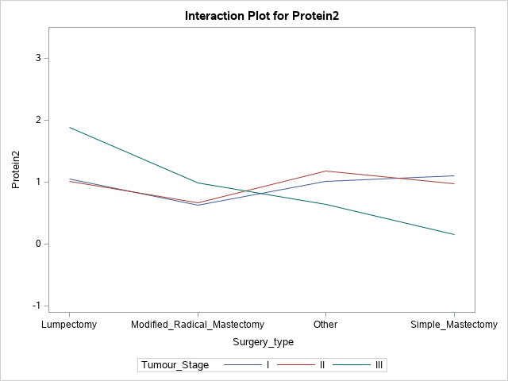

The GLM Procedure

Dependent Variable: Protein3

| Source | DF | Sum of Squares | Mean Square | F Value | Pr > F |
| --- | --- | --- | --- | --- | --- |
| Model | 11 | 4.4832742 | 0.4075704 | 1.19 | 0.2954 |
| Error | 309 | 106.1475591 | 0.3435196 |  |  |
| Corrected Total | 320 | 110.6308333 |  |  |  |

| R-Square | Coeff Var | Root MSE | Protein3 Mean |
| --- | --- | --- | --- |
| 0.040525 | -628.3391 | 0.586105 | -0.093279 |

| Source | DF | Type III SS | Mean Square | F Value | Pr > F |
| --- | --- | --- | --- | --- | --- |
| Surgery_t*Tumour_Sta | 11 | 4.48327417 | 0.40757038 | 1.19 | 0.2954 |

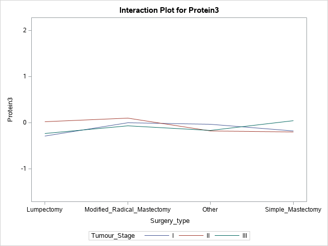

The GLM Procedure

Dependent Variable: Protein4

| Source | DF | Sum of Squares | Mean Square | F Value | Pr > F |
| --- | --- | --- | --- | --- | --- |
| Model | 11 | 4.2562059 | 0.3869278 | 1.00 | 0.4476 |
| Error | 309 | 119.7423816 | 0.3875158 |  |  |
| Corrected Total | 320 | 123.9985875 |  |  |  |

| R-Square | Coeff Var | Root MSE | Protein4 Mean |
| --- | --- | --- | --- |
| 0.034325 | 7063.678 | 0.622508 | 0.008813 |

| Source | DF | Type III SS | Mean Square | F Value | Pr > F |
| --- | --- | --- | --- | --- | --- |
| Surgery_t*Tumour_Sta | 11 | 4.25620594 | 0.38692781 | 1.00 | 0.4476 |

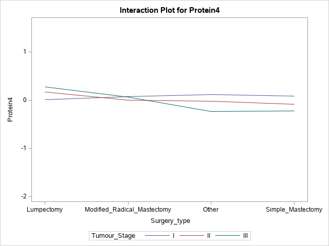

The GLM Procedure

Multivariate Analysis of Variance

| Characteristic Roots and Vectors of: E Inverse * H, where H = Type III SSCP Matrix for Surgery_t*Tumour_Sta E = Error SSCP Matrix Characteristic Root | Characteristic Roots and Vectors of: E Inverse * H, where H = Type III SSCP Matrix for Surgery_t*Tumour_Sta E = Error SSCP Matrix Percent | Characteristic Roots and Vectors of: E Inverse * H, where H = Type III SSCP Matrix for Surgery_t*Tumour_Sta E = Error SSCP Matrix Characteristic Vector V'EV=1 Protein2 | Characteristic Roots and Vectors of: E Inverse * H, where H = Type III SSCP Matrix for Surgery_t*Tumour_Sta E = Error SSCP Matrix Characteristic Vector V'EV=1 Protein3 | Characteristic Roots and Vectors of: E Inverse * H, where H = Type III SSCP Matrix for Surgery_t*Tumour_Sta E = Error SSCP Matrix Characteristic Vector V'EV=1 Protein4 |
| --- | --- | --- | --- | --- |
| 0.10742871 | 67.64 | 0.06111630 | 0.01176976 | 0.03302307 |
| 0.04600989 | 28.97 | -0.00052373 | 0.08153757 | 0.04400795 |
| 0.00539317 | 3.40 | -0.03519278 | -0.06747809 | 0.07374630 |

| MANOVA Test Criteria and F Approximations for the Hypothesis of No Overall Surgery_t*Tumour_Sta Effect H = Type III SSCP Matrix for Surgery_t*Tumour_Sta E = Error SSCP Matrix S=3 M=3.5 N=152.5 Statistic | MANOVA Test Criteria and F Approximations for the Hypothesis of No Overall Surgery_t*Tumour_Sta Effect H = Type III SSCP Matrix for Surgery_t*Tumour_Sta E = Error SSCP Matrix S=3 M=3.5 N=152.5 Value | MANOVA Test Criteria and F Approximations for the Hypothesis of No Overall Surgery_t*Tumour_Sta Effect H = Type III SSCP Matrix for Surgery_t*Tumour_Sta E = Error SSCP Matrix S=3 M=3.5 N=152.5 F Value | MANOVA Test Criteria and F Approximations for the Hypothesis of No Overall Surgery_t*Tumour_Sta Effect H = Type III SSCP Matrix for Surgery_t*Tumour_Sta E = Error SSCP Matrix S=3 M=3.5 N=152.5 Num DF | MANOVA Test Criteria and F Approximations for the Hypothesis of No Overall Surgery_t*Tumour_Sta Effect H = Type III SSCP Matrix for Surgery_t*Tumour_Sta E = Error SSCP Matrix S=3 M=3.5 N=152.5 Den DF | MANOVA Test Criteria and F Approximations for the Hypothesis of No Overall Surgery_t*Tumour_Sta Effect H = Type III SSCP Matrix for Surgery_t*Tumour_Sta E = Error SSCP Matrix S=3 M=3.5 N=152.5 Pr > F |
| --- | --- | --- | --- | --- | --- |
| Wilks' Lambda | 0.85864273 | 1.46 | 33 | 905.18 | 0.0478 |
| Pillai's Trace | 0.14635767 | 1.44 | 33 | 927 | 0.0527 |
| Hotelling-Lawley Trace | 0.15883177 | 1.47 | 33 | 707.93 | 0.0443 |
| Roy's Greatest Root | 0.10742871 | 3.02 | 11 | 309 | 0.0008 |

NOTE: F Statistic for Roy's Greatest Root is an upper bound.